# Customer churn

Import relevant packages

```python
import numpy as np
import pandas as pd
import matplotlib as plt
import pickle

from sklearn.model_selection import train_test_split
from sklearn.model_selection import GridSearchCV
from sklearn import metrics
```

Obtain training and test data

```python
train=pd.read_csv(r'C:\Users\ivan5\Dropbox\Coursera\2. Kaggle\Customer Churn\train.csv')
test=pd.read_csv(r'C:\Users\ivan5\Dropbox\Coursera\2. Kaggle\Customer Churn\test.csv')
```

Obtain information on columns

```python
train.info()
```

```
<class 'pandas.core.frame.DataFrame'>
RangeIndex: 594194 entries, 0 to 594193
Data columns (total 21 columns):
 #   Column            Non-Null Count   Dtype
---  ------            --------------   -----
 0   id                594194 non-null  int64
 1   gender            594194 non-null  object
 2   SeniorCitizen     594194 non-null  int64
 3   Partner           594194 non-null  object
 4   Dependents        594194 non-null  object
 5   tenure            594194 non-null  int64
 6   PhoneService      594194 non-null  object
 7   MultipleLines     594194 non-null  object
 8   InternetService   594194 non-null  object
 9   OnlineSecurity    594194 non-null  object
 10  OnlineBackup      594194 non-null  object
 11  DeviceProtection  594194 non-null  object
 12  TechSupport       594194 non-null  object
 13  StreamingTV       594194 non-null  object
 14  StreamingMovies   594194 non-null  object
 15  Contract          594194 non-null  object
 16  PaperlessBilling  594194 non-null  object
 17  PaymentMethod     594194 non-null  object
 18  MonthlyCharges    594194 non-null  float64
 19  TotalCharges      594194 non-null  float64
 20  Churn             594194 non-null  object
dtypes: float64(2), int64(3), object(16)
memory usage: 95.2+ MB
```

```python
train.describe(include='all')
```

|  | id | gender | SeniorCitizen | Partner | Dependents | tenure | PhoneService | MultipleLines | InternetService | OnlineSecurity | ... | DeviceProtection | TechSupport | StreamingTV | StreamingMovies | Contract | PaperlessBilling | PaymentMethod | MonthlyCharges | TotalCharges | Churn |
| --- | --- | --- | --- | --- | --- | --- | --- | --- | --- | --- | --- | --- | --- | --- | --- | --- | --- | --- | --- | --- | --- |
| count | 594194.000000 | 594194 | 594194.000000 | 594194 | 594194 | 594194.000000 | 594194 | 594194 | 594194 | 594194 | ... | 594194 | 594194 | 594194 | 594194 | 594194 | 594194 | 594194 | 594194.000000 | 594194.000000 | 594194 |
| unique | NaN | 2 | NaN | 2 | 2 | NaN | 2 | 3 | 3 | 3 | ... | 3 | 3 | 3 | 3 | 3 | 2 | 4 | NaN | NaN | 2 |
| top | NaN | Female | NaN | Yes | No | NaN | Yes | No | Fiber optic | No | ... | No | No | Yes | Yes | Month-to-month | Yes | Electronic check | NaN | NaN | No |
| freq | NaN | 298738 | NaN | 309554 | 414362 | NaN | 557893 | 283384 | 272386 | 289474 | ... | 247377 | 288571 | 240301 | 241435 | 298918 | 365579 | 215372 | NaN | NaN | 460377 |
| mean | 297096.500000 | NaN | 0.114102 | NaN | NaN | 36.577258 | NaN | NaN | NaN | NaN | ... | NaN | NaN | NaN | NaN | NaN | NaN | NaN | 65.866223 | 2494.377057 | NaN |
| std | 171529.177263 | NaN | 0.317936 | NaN | NaN | 25.061922 | NaN | NaN | NaN | NaN | ... | NaN | NaN | NaN | NaN | NaN | NaN | NaN | 31.067444 | 2353.916710 | NaN |
| min | 0.000000 | NaN | 0.000000 | NaN | NaN | 1.000000 | NaN | NaN | NaN | NaN | ... | NaN | NaN | NaN | NaN | NaN | NaN | NaN | 18.250000 | 18.800000 | NaN |
| 25% | 148548.250000 | NaN | 0.000000 | NaN | NaN | 12.000000 | NaN | NaN | NaN | NaN | ... | NaN | NaN | NaN | NaN | NaN | NaN | NaN | 29.900000 | 639.650000 | NaN |
| 50% | 297096.500000 | NaN | 0.000000 | NaN | NaN | 35.000000 | NaN | NaN | NaN | NaN | ... | NaN | NaN | NaN | NaN | NaN | NaN | NaN | 74.100000 | 1433.650000 | NaN |
| 75% | 445644.750000 | NaN | 0.000000 | NaN | NaN | 62.000000 | NaN | NaN | NaN | NaN | ... | NaN | NaN | NaN | NaN | NaN | NaN | NaN | 90.800000 | 4263.800000 | NaN |
| max | 594193.000000 | NaN | 1.000000 | NaN | NaN | 72.000000 | NaN | NaN | NaN | NaN | ... | NaN | NaN | NaN | NaN | NaN | NaN | NaN | 118.750000 | 8684.800000 | NaN |

11 rows × 21 columns

```python
train.head(10)
```

|  | id | gender | SeniorCitizen | Partner | Dependents | tenure | PhoneService | MultipleLines | InternetService | OnlineSecurity | ... | DeviceProtection | TechSupport | StreamingTV | StreamingMovies | Contract | PaperlessBilling | PaymentMethod | MonthlyCharges | TotalCharges | Churn |
| --- | --- | --- | --- | --- | --- | --- | --- | --- | --- | --- | --- | --- | --- | --- | --- | --- | --- | --- | --- | --- | --- |
| 0 | 0 | Male | 0 | Yes | Yes | 29 | Yes | No | DSL | Yes | ... | Yes | Yes | No | No | One year | Yes | Mailed check | 60.10 | 1653.85 | No |
| 1 | 1 | Male | 0 | Yes | Yes | 58 | Yes | No | DSL | Yes | ... | No | Yes | Yes | No | Two year | No | Credit card (automatic) | 69.50 | 3778.20 | No |
| 2 | 2 | Male | 0 | Yes | No | 58 | Yes | Yes | Fiber optic | No | ... | No | No | Yes | Yes | Month-to-month | Yes | Electronic check | 100.40 | 5841.35 | No |
| 3 | 3 | Female | 0 | No | No | 1 | Yes | No | Fiber optic | No | ... | No | No | No | No | Month-to-month | Yes | Electronic check | 69.70 | 70.70 | Yes |
| 4 | 4 | Female | 0 | No | No | 1 | Yes | No | Fiber optic | No | ... | No | No | No | No | Month-to-month | Yes | Electronic check | 70.45 | 70.45 | Yes |
| 5 | 5 | Male | 0 | Yes | Yes | 1 | Yes | No | No | No internet service | ... | No internet service | No internet service | No internet service | No internet service | Month-to-month | Yes | Bank transfer (automatic) | 20.20 | 20.20 | No |
| 6 | 6 | Female | 0 | Yes | Yes | 24 | Yes | No | No | No internet service | ... | No internet service | No internet service | No internet service | No internet service | Month-to-month | No | Mailed check | 20.40 | 533.60 | No |
| 7 | 7 | Male | 0 | Yes | No | 72 | Yes | Yes | DSL | Yes | ... | Yes | Yes | Yes | Yes | Two year | No | Electronic check | 92.00 | 6827.50 | No |
| 8 | 8 | Female | 1 | No | No | 1 | Yes | Yes | Fiber optic | No | ... | Yes | No | No | No | Month-to-month | Yes | Electronic check | 79.55 | 79.55 | Yes |
| 9 | 9 | Male | 0 | No | No | 55 | Yes | No | Fiber optic | Yes | ... | No | No | Yes | Yes | Month-to-month | Yes | Electronic check | 100.05 | 4738.30 | No |

10 rows × 21 columns

The target predictor valuable is Churn. Tenure, contract and total charges might provide strong weight on the predictor. Maybe even feature engineering a count of the services provided. Type of internet might also be good, fiber optic is usually the fastest.

```python
train['Churn'].value_counts(normalize=True)
```

```
Churn
No     0.774792
Yes    0.225208
Name: proportion, dtype: float64
```

We have an unbalanced dataset, with just 22.52% of records providing data on churned customers, however it is very usable. Now, let's review value counts for each categorical column and see what this tells us.

```python
for x in train.columns:
    if train[x].dtype == 'float64' or train[x].dtype == 'int64':
        continue
    else:
        print(x, ':', train[x].value_counts(normalize=True))
```

```
gender : gender
Female    0.502762
Male      0.497238
Name: proportion, dtype: float64
Partner : Partner
Yes    0.520965
No     0.479035
Name: proportion, dtype: float64
Dependents : Dependents
No     0.697351
Yes    0.302649
Name: proportion, dtype: float64
PhoneService : PhoneService
Yes    0.938907
No     0.061093
Name: proportion, dtype: float64
MultipleLines : MultipleLines
No                  0.476922
Yes                 0.461985
No phone service    0.061093
Name: proportion, dtype: float64
InternetService : InternetService
Fiber optic    0.458413
DSL            0.304751
No             0.236837
Name: proportion, dtype: float64
OnlineSecurity : OnlineSecurity
No                     0.487171
Yes                    0.275992
No internet service    0.236837
Name: proportion, dtype: float64
OnlineBackup : OnlineBackup
No                     0.420878
Yes                    0.342286
No internet service    0.236837
Name: proportion, dtype: float64
DeviceProtection : DeviceProtection
No                     0.416324
Yes                    0.346840
No internet service    0.236837
```

[output cut: 20 more lines]

```
Name: proportion, dtype: float64
PaperlessBilling : PaperlessBilling
Yes    0.615252
No     0.384748
Name: proportion, dtype: float64
PaymentMethod : PaymentMethod
Electronic check             0.362461
Credit card (automatic)      0.225019
Mailed check                 0.208277
Bank transfer (automatic)    0.204243
Name: proportion, dtype: float64
Churn : Churn
No     0.774792
Yes    0.225208
Name: proportion, dtype: float64
```

Seeems like all the sub services related to having internet services have similar class distribution. What most calls for my attention as predictive features are: Contract, dependents and maybe feature-engineer a count of subservices for the ones that have internet service.

## EDA: Univariate Analysis (Distributions)

Examine distributions of numerical and categorical features to identify patterns and outliers.

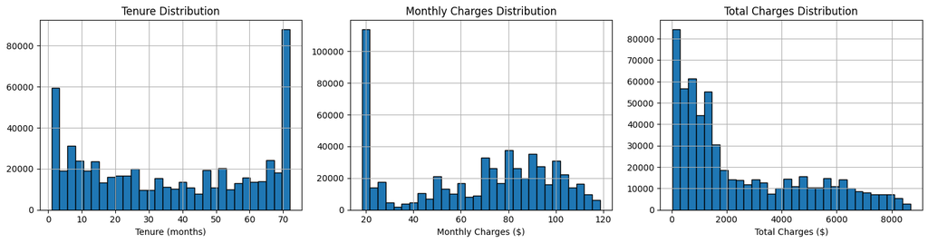

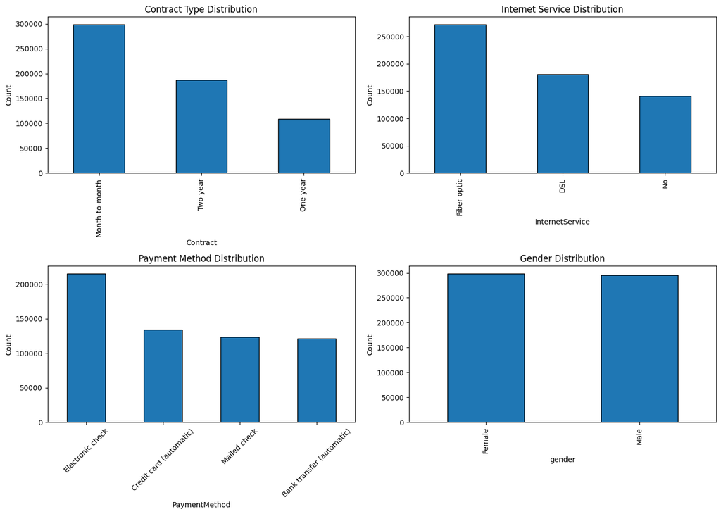

```python
import seaborn as sns
import matplotlib.pyplot as plt

# Univariate Analysis: Numerical Features
fig, axes = plt.subplots(1, 3, figsize=(15, 4))
train['tenure'].hist(bins=30, ax=axes[0], edgecolor='black')
axes[0].set_title('Tenure Distribution')
axes[0].set_xlabel('Tenure (months)')

train['MonthlyCharges'].hist(bins=30, ax=axes[1], edgecolor='black')
axes[1].set_title('Monthly Charges Distribution')
axes[1].set_xlabel('Monthly Charges ($)')

train['TotalCharges'].hist(bins=30, ax=axes[2], edgecolor='black')
axes[2].set_title('Total Charges Distribution')
axes[2].set_xlabel('Total Charges ($)')
plt.tight_layout()
plt.show()

# Univariate Analysis: Key Categorical Features
fig, axes = plt.subplots(2, 2, figsize=(14, 10))
train['Contract'].value_counts().plot(kind='bar', ax=axes[0, 0], edgecolor='black')
axes[0, 0].set_title('Contract Type Distribution')
axes[0, 0].set_ylabel('Count')

train['InternetService'].value_counts().plot(kind='bar', ax=axes[0, 1], edgecolor='black')
axes[0, 1].set_title('Internet Service Distribution')
axes[0, 1].set_ylabel('Count')

train['PaymentMethod'].value_counts().plot(kind='bar', ax=axes[1, 0], edgecolor='black')
axes[1, 0].set_title('Payment Method Distribution')
axes[1, 0].set_ylabel('Count')
axes[1, 0].tick_params(axis='x', rotation=45)

train['gender'].value_counts().plot(kind='bar', ax=axes[1, 1], edgecolor='black')
axes[1, 1].set_title('Gender Distribution')
axes[1, 1].set_ylabel('Count')

plt.tight_layout()
plt.show()
```

## EDA: Bivariate Analysis (Relationships with Churn)

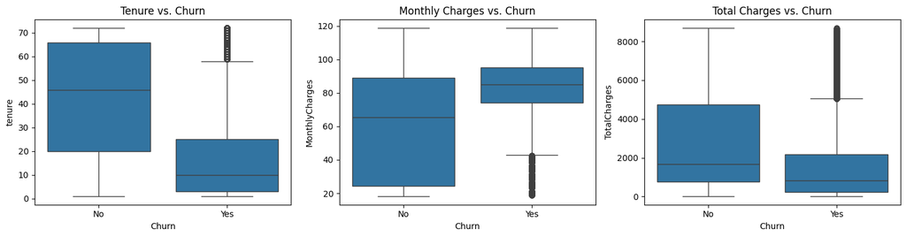

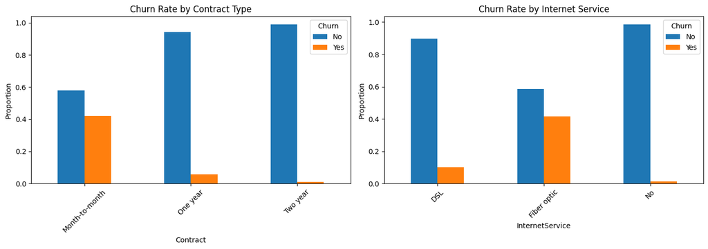

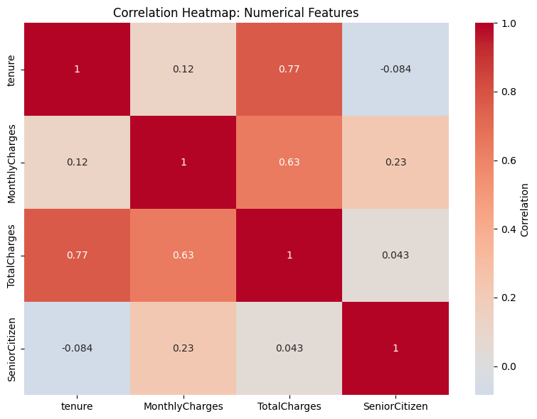

```
Key observations:
- Churn rate overall: Churn
No     0.774792
Yes    0.225208
Name: proportion, dtype: float64
- Month-to-month contract churn rate: 42.05%
- Two year contract churn rate: 1.00%
```

```python
# Bivariate Analysis: Box plots for numerical features vs. Churn
fig, axes = plt.subplots(1, 3, figsize=(15, 4))
sns.boxplot(x='Churn', y='tenure', data=train, ax=axes[0])
axes[0].set_title('Tenure vs. Churn')

sns.boxplot(x='Churn', y='MonthlyCharges', data=train, ax=axes[1])
axes[1].set_title('Monthly Charges vs. Churn')

sns.boxplot(x='Churn', y='TotalCharges', data=train, ax=axes[2])
axes[2].set_title('Total Charges vs. Churn')
plt.tight_layout()
plt.show()

# Bivariate Analysis: Churn rate by Contract and InternetService
fig, axes = plt.subplots(1, 2, figsize=(14, 5))
pd.crosstab(train['Contract'], train['Churn'], normalize='index').plot(kind='bar', ax=axes[0], stacked=False)
axes[0].set_title('Churn Rate by Contract Type')
axes[0].set_ylabel('Proportion')
axes[0].tick_params(axis='x', rotation=45)

pd.crosstab(train['InternetService'], train['Churn'], normalize='index').plot(kind='bar', ax=axes[1], stacked=False)
axes[1].set_title('Churn Rate by Internet Service')
axes[1].set_ylabel('Proportion')
axes[1].tick_params(axis='x', rotation=45)
plt.tight_layout()
plt.show()

# Correlation heatmap (numerical features only)
numerical_cols = ['tenure', 'MonthlyCharges', 'TotalCharges', 'SeniorCitizen']
correlation_matrix = train[numerical_cols].corr()
plt.figure(figsize=(8, 6))
sns.heatmap(correlation_matrix, annot=True, cmap='coolwarm', center=0, cbar_kws={'label': 'Correlation'})
plt.title('Correlation Heatmap: Numerical Features')
plt.tight_layout()
plt.show()

print("Key observations:")
print(f"- Churn rate overall: {train['Churn'].value_counts(normalize=True)}")
print(f"- Month-to-month contract churn rate: {train[train['Contract']=='Month-to-month']['Churn'].value_counts(normalize=True)['Yes']:.2%}")
print(f"- Two year contract churn rate: {train[train['Contract']=='Two year']['Churn'].value_counts(normalize=True)['Yes']:.2%}")
```

## Feature Engineering: New Features from Existing Ones

Create meaningful features that capture business logic and non-linear relationships.

```
New Features Created:
1. total_services: count    594194.000000
mean          2.053368
std           1.968652
min           0.000000
25%           0.000000
50%           2.000000
75%           4.000000
max           6.000000
Name: total_services, dtype: float64

2. has_internet: has_internet
1    453467
0    140727
Name: count, dtype: int64

3. tenure_group:
tenure_group
Loyal (25m+)            355524
New (0-12m)             152646
Established (13-24m)     86024
Name: count, dtype: int64

4. avg_monthly_charge: count    594194.000000
mean         61.527166
std          36.749533
min           0.724074
25%          25.469640
50%          64.981429
75%          86.954348
max        1046.908333
Name: avg_monthly_charge, dtype: float64
   charge_per_service: count    594194.000000
mean         26.317482
std          15.137512
min           4.016667
25%          18.233333
50%          20.650000
75%          28.266667
max          93.700000
Name: charge_per_service, dtype: float64

5. new_month_to_month: new_month_to_month
0    516911
1     77283
Name: count, dtype: int64

6. senior_with_dependents: senior_with_dependents
0    592401
1      1793
Name: count, dtype: int64
   has_family: has_family
1    323040
0    271154
Name: count, dtype: int64
```

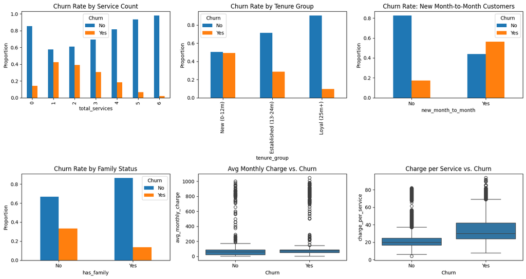

```
Feature engineering complete! New engineered datasets: train_fe, test_fe
```

```python
# Create feature engineering helper function
def engineer_features(df):
    """
    Engineer new features from existing ones.
    """
    df_engineered = df.copy()

    # 1. Service Count: Sum of all subscribed services (Yes values)
    service_cols = ['OnlineSecurity', 'OnlineBackup', 'DeviceProtection',
                    'TechSupport', 'StreamingTV', 'StreamingMovies']
    df_engineered['total_services'] = (df_engineered[service_cols] == 'Yes').sum(axis=1)

    # 2. Has Internet: Binary flag
    df_engineered['has_internet'] = (df_engineered['InternetService'] != 'No').astype(int)

    # 3. Tenure Bins: Categorize tenure into meaningful groups
    df_engineered['tenure_group'] = pd.cut(df_engineered['tenure'],
                                            bins=[0, 12, 24, 72],
                                            labels=['New (0-12m)', 'Established (13-24m)', 'Loyal (25m+)'])

    # 4. Charge Ratios: Average monthly charge and charge per service
    df_engineered['avg_monthly_charge'] = df_engineered['TotalCharges'] / (df_engineered['tenure'] + 1)
    df_engineered['charge_per_service'] = df_engineered['MonthlyCharges'] / (df_engineered['total_services'] + 1)

    # 5. Contract Tenure Interaction: High-risk segment (month-to-month AND new customer)
    df_engineered['new_month_to_month'] = ((df_engineered['Contract'] == 'Month-to-month') &
                                            (df_engineered['tenure'] < 6)).astype(int)

    # 6. Senior/Dependent Flags
    df_engineered['senior_with_dependents'] = ((df_engineered['SeniorCitizen'] == 1) &
                                                (df_engineered['Dependents'] == 'Yes')).astype(int)
    df_engineered['has_family'] = ((df_engineered['Partner'] == 'Yes') |
                                    (df_engineered['Dependents'] == 'Yes')).astype(int)

    return df_engineered

# Apply feature engineering to train and test sets
train_fe = engineer_features(train)
test_fe = engineer_features(test)

# Display new features summary
print("New Features Created:")
print(f"1. total_services: {train_fe['total_services'].describe()}")
print(f"\n2. has_internet: {train_fe['has_internet'].value_counts()}")
print(f"\n3. tenure_group:\n{train_fe['tenure_group'].value_counts()}")
print(f"\n4. avg_monthly_charge: {train_fe['avg_monthly_charge'].describe()}")
print(f"   charge_per_service: {train_fe['charge_per_service'].describe()}")
print(f"\n5. new_month_to_month: {train_fe['new_month_to_month'].value_counts()}")
print(f"\n6. senior_with_dependents: {train_fe['senior_with_dependents'].value_counts()}")
print(f"   has_family: {train_fe['has_family'].value_counts()}")

# Visualize relationship between new features and Churn
fig, axes = plt.subplots(2, 3, figsize=(15, 8))

# total_services vs Churn
pd.crosstab(train_fe['total_services'], train_fe['Churn'], normalize='index').plot(
    kind='bar', ax=axes[0, 0])
axes[0, 0].set_title('Churn Rate by Service Count')
axes[0, 0].set_ylabel('Proportion')

# tenure_group vs Churn
pd.crosstab(train_fe['tenure_group'], train_fe['Churn'], normalize='index').plot(
    kind='bar', ax=axes[0, 1])
axes[0, 1].set_title('Churn Rate by Tenure Group')
axes[0, 1].set_ylabel('Proportion')

# new_month_to_month vs Churn
pd.crosstab(train_fe['new_month_to_month'], train_fe['Churn'], normalize='index').plot(
    kind='bar', ax=axes[0, 2])
axes[0, 2].set_title('Churn Rate: New Month-to-Month Customers')
axes[0, 2].set_ylabel('Proportion')
axes[0, 2].set_xticklabels(['No', 'Yes'], rotation=0)

# has_family vs Churn
pd.crosstab(train_fe['has_family'], train_fe['Churn'], normalize='index').plot(
    kind='bar', ax=axes[1, 0])
axes[1, 0].set_title('Churn Rate by Family Status')
axes[1, 0].set_ylabel('Proportion')
axes[1, 0].set_xticklabels(['No', 'Yes'], rotation=0)

# avg_monthly_charge vs Churn
sns.boxplot(x='Churn', y='avg_monthly_charge', data=train_fe, ax=axes[1, 1])
axes[1, 1].set_title('Avg Monthly Charge vs. Churn')

# charge_per_service vs Churn
sns.boxplot(x='Churn', y='charge_per_service', data=train_fe, ax=axes[1, 2])
axes[1, 2].set_title('Charge per Service vs. Churn')

plt.tight_layout()
plt.show()

print("\nFeature engineering complete! New engineered datasets: train_fe, test_fe")
```

## Further explore relevant features

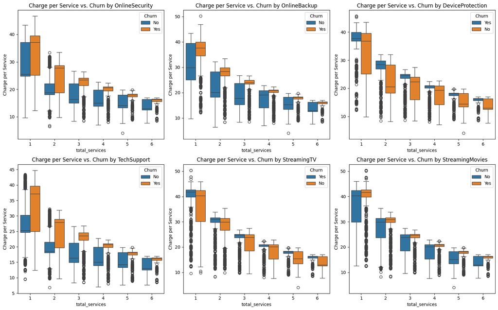

```python
service_cols = ['OnlineSecurity', 'OnlineBackup', 'DeviceProtection',
                    'TechSupport', 'StreamingTV', 'StreamingMovies']

#Create a grid of subplots for each service (2 rows x 3 columns)
fig, axes = plt.subplots(2, 3, figsize=(16, 10))
axes = axes.flatten()  # Flatten to make indexing easier

#Create a boxplot for each service
for idx, service in enumerate(service_cols):
    sns.boxplot(x='total_services', y='charge_per_service', data=train_fe[train_fe[service]=="Yes"], hue="Churn", ax=axes[idx])
    axes[idx].set_title(f'Charge per Service vs. Churn by {service}')
    axes[idx].set_ylabel('Charge per Service')

plt.tight_layout()
plt.show()
```

Churners in charges per service are mostly distributed in the higher end of charge per service. Looking at the plots we can tell that the company makes discounts based on the number of services they have acquired, however the trend is clear among all of them. I would suggest running an experiment where the cost is lowered just below the 1st quartile of the churners and see if it has any impact in the churn rate. Run a cost to benefit analysis, revenue per customer vs overall customer revenue and retention.

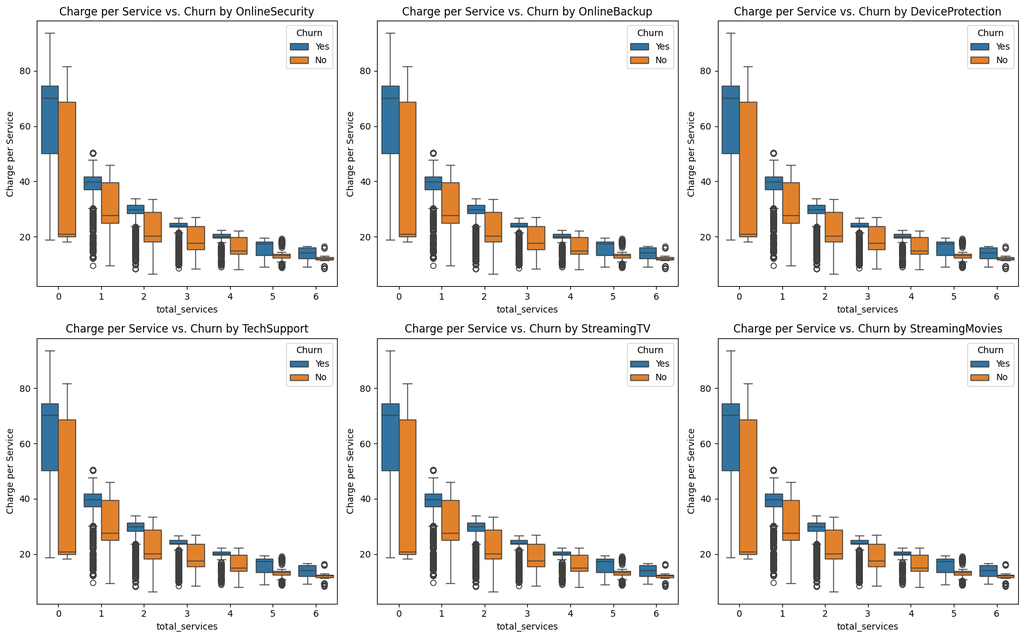

```python
service_cols = ['OnlineSecurity', 'OnlineBackup', 'DeviceProtection',
                    'TechSupport', 'StreamingTV', 'StreamingMovies']

#Create a grid of subplots for each service (2 rows x 3 columns)
fig, axes = plt.subplots(2, 3, figsize=(16, 10))
axes = axes.flatten()  # Flatten to make indexing easier

#Create a boxplot for each service
for idx, service in enumerate(service_cols):
    sns.boxplot(x='total_services', y='charge_per_service', data=train_fe[train_fe["tenure_group"]=="New (0-12m)"], hue="Churn", ax=axes[idx])
    axes[idx].set_title(f'Charge per Service vs. Churn by {service}')
    axes[idx].set_ylabel('Charge per Service')

plt.tight_layout()
plt.show()
```

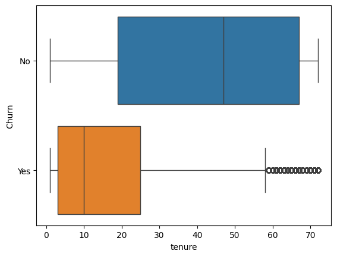

```python
#Visualize low tenure customers with a boxplot, filtering by having internet service and having a hue in churn
sns.boxplot(x='tenure', y='Churn', data=train_fe[train_fe['has_internet']==1], hue='Churn')
```

```
Number customers who do not have internet service and churn: 2014
Number customers who have internet service and churn: 131803
Number customers who do not have internet service and do not churn: 138713
Number customers who have internet service and do not churn: 321664
```

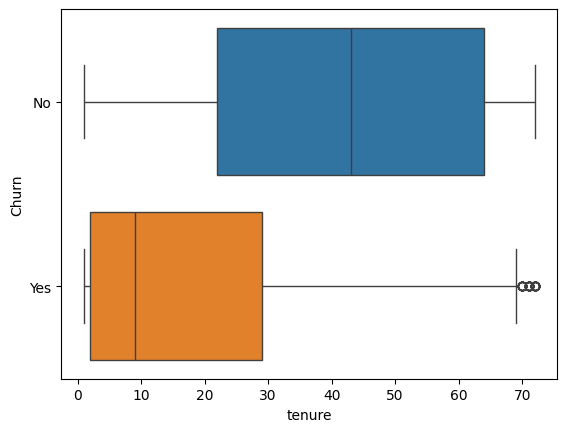

```python
#Visualize low tenure customers with a boxplot, filtering by not having internet service and having a hue in churn
sns.boxplot(x='tenure', y='Churn', data=train_fe[train_fe['has_internet']==0], hue='Churn')
print("Number customers who do not have internet service and churn:", len(train_fe[(train_fe['has_internet']==0) & (train_fe['Churn']=='Yes')]))
print("Number customers who have internet service and churn:", len(train_fe[(train_fe['has_internet']==1) & (train_fe['Churn']=='Yes')]))
print("Number customers who do not have internet service and do not churn:", len(train_fe[(train_fe['has_internet']==0) & (train_fe['Churn']=='No')]))
print("Number customers who have internet service and do not churn:", len(train_fe[(train_fe['has_internet']==1) & (train_fe['Churn']=='No')]))
```

## CatBoost Model Development with GridSearchCV

Build and optimize a CatBoost classifier using GridSearchCV with precision as the primary metric.

```python
from sklearn.preprocessing import LabelEncoder
from sklearn.model_selection import train_test_split
from sklearn.metrics import confusion_matrix, classification_report, precision_score, recall_score, f1_score, accuracy_score
from sklearn.model_selection import GridSearchCV
import warnings
warnings.filterwarnings('ignore')

# Prepare data: Drop avg_monthly_charge and id columns
df_processed = train_fe.copy()

# Convert tenure_group (categorical dtype) to string
df_processed['tenure_group'] = df_processed['tenure_group'].astype(str)

X = df_processed.drop(['id', 'Churn', 'avg_monthly_charge'], axis=1)
y = df_processed['Churn'].map({'Yes': 1, 'No': 0})

# Identify categorical and numerical columns
categorical_cols = X.select_dtypes(include=['object']).columns.tolist()
numerical_cols = X.select_dtypes(include=['int64', 'float64']).columns.tolist()

print(f"Categorical features ({len(categorical_cols)}): {categorical_cols}")
print(f"Numerical features ({len(numerical_cols)}): {numerical_cols}")

# Encode categorical features for sklearn compatibility
label_encoders = {}
X_encoded = X.copy()

for col in categorical_cols:
    le = LabelEncoder()
    X_encoded[col] = le.fit_transform(X[col].astype(str))
    label_encoders[col] = le

# Split data (80/20)
X_train, X_test, y_train, y_test = train_test_split(
    X_encoded, y, test_size=0.2, random_state=42, stratify=y
)

print(f"\nTrain set: {X_train.shape}, Test set: {X_test.shape}")
print(f"Class distribution in train: {y_train.value_counts(normalize=True)}")

# Define parameter grid for GridSearchCV
param_grid = {
    'depth': [3, 5, 7],
    'learning_rate': [0.01, 0.05, 0.1],
    'iterations': [100, 200, 300],
    'l2_leaf_reg': [1, 3, 5]
}

print("\nStarting GridSearchCV with parameter grid:")
for key, val in param_grid.items():
    print(f"  {key}: {val}")
```

```
Categorical features (16): ['gender', 'Partner', 'Dependents', 'PhoneService', 'MultipleLines', 'InternetService', 'OnlineSecurity', 'OnlineBackup', 'DeviceProtection', 'TechSupport', 'StreamingTV', 'StreamingMovies', 'Contract', 'PaperlessBilling', 'PaymentMethod', 'tenure_group']
Numerical features (6): ['SeniorCitizen', 'tenure', 'MonthlyCharges', 'TotalCharges', 'total_services', 'charge_per_service']

Train set: (475355, 26), Test set: (118839, 26)
Class distribution in train: Churn
0    0.774791
1    0.225209
Name: proportion, dtype: float64

Starting GridSearchCV with parameter grid:
  depth: [3, 5, 7]
  learning_rate: [0.01, 0.05, 0.1]
  iterations: [100, 200, 300]
  l2_leaf_reg: [1, 3, 5]
```

```python
# Run GridSearchCV with Precision as primary metric
# Using cv=5 for 5-fold cross-validation
catboost_base = CatBoostClassifier(
    verbose=False,
    random_state=42,
    scale_pos_weight=1.5  # Weight positive class due to imbalance
)

grid_search = GridSearchCV(
    estimator=catboost_base,
    param_grid=param_grid,
    cv=5,
    scoring='precision',  # Primary metric: Precision
    n_jobs=-1,
    verbose=1
)

print("Running GridSearchCV... (this may take a minute)")
grid_search.fit(X_train, y_train)

# Display best parameters and scores
print(f"\nBest parameters: {grid_search.best_params_}")
print(f"Best Precision (CV mean): {grid_search.best_score_:.4f}")

# Train final model on best parameters
best_model = grid_search.best_estimator_

# Predictions on test set
y_pred = best_model.predict(X_test)
y_pred_proba = best_model.predict_proba(X_test)[:, 1]

# Calculate all metrics
precision = precision_score(y_test, y_pred)
recall = recall_score(y_test, y_pred)
f1 = f1_score(y_test, y_pred)
accuracy = accuracy_score(y_test, y_pred)

print("\n=== MODEL PERFORMANCE ON TEST SET ===")
print(f"Precision:  {precision:.4f}")
print(f"Recall:     {recall:.4f}")
print(f"F1-Score:   {f1:.4f}")
print(f"Accuracy:   {accuracy:.4f}")

print("\nClassification Report:")
print(classification_report(y_test, y_pred, target_names=['No Churn', 'Churn']))
```

```
Running GridSearchCV... (this may take a minute)
Fitting 5 folds for each of 81 candidates, totalling 405 fits

Best parameters: {'depth': 7, 'iterations': 300, 'l2_leaf_reg': 3, 'learning_rate': 0.1}
Best Precision (CV mean): 0.6587

=== MODEL PERFORMANCE ON TEST SET ===
Precision:  0.6593
Recall:     0.7491
F1-Score:   0.7014
Accuracy:   0.8563

Classification Report:
              precision    recall  f1-score   support

    No Churn       0.92      0.89      0.91     92076
       Churn       0.66      0.75      0.70     26763

    accuracy                           0.86    118839
   macro avg       0.79      0.82      0.80    118839
weighted avg       0.86      0.86      0.86    118839
```

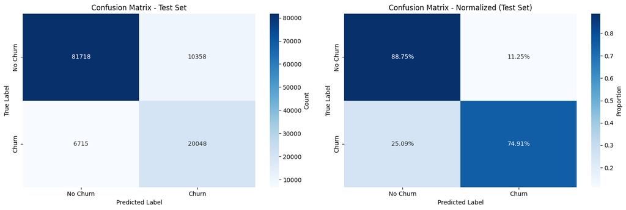

```
Confusion Matrix Breakdown:
  True Negatives (TN):  81718 - Correctly predicted No Churn
  False Positives (FP): 10358 - Incorrectly predicted Churn (Type I Error)
  False Negatives (FN): 6715 - Incorrectly predicted No Churn (Type II Error)
  True Positives (TP):  20048 - Correctly predicted Churn

Key Insights:
  - Specificity (TN rate): 0.8875 - Ability to identify non-churners
  - Sensitivity/Recall (TP rate): 0.7491 - Ability to identify churners
```

```python
# Confusion Matrix
cm = confusion_matrix(y_test, y_pred)
fig, axes = plt.subplots(1, 2, figsize=(15, 5))

# Heatmap of confusion matrix
sns.heatmap(cm, annot=True, fmt='d', cmap='Blues', ax=axes[0],
            xticklabels=['No Churn', 'Churn'], yticklabels=['No Churn', 'Churn'],
            cbar_kws={'label': 'Count'})
axes[0].set_title('Confusion Matrix - Test Set')
axes[0].set_ylabel('True Label')
axes[0].set_xlabel('Predicted Label')

# Normalized confusion matrix (percentages)
cm_normalized = cm.astype('float') / cm.sum(axis=1)[:, np.newaxis]
sns.heatmap(cm_normalized, annot=True, fmt='.2%', cmap='Blues', ax=axes[1],
            xticklabels=['No Churn', 'Churn'], yticklabels=['No Churn', 'Churn'],
            cbar_kws={'label': 'Proportion'})
axes[1].set_title('Confusion Matrix - Normalized (Test Set)')
axes[1].set_ylabel('True Label')
axes[1].set_xlabel('Predicted Label')

plt.tight_layout()
plt.show()

# Detailed confusion matrix interpretation
tn, fp, fn, tp = cm.ravel()
print(f"\nConfusion Matrix Breakdown:")
print(f"  True Negatives (TN):  {tn} - Correctly predicted No Churn")
print(f"  False Positives (FP): {fp} - Incorrectly predicted Churn (Type I Error)")
print(f"  False Negatives (FN): {fn} - Incorrectly predicted No Churn (Type II Error)")
print(f"  True Positives (TP):  {tp} - Correctly predicted Churn")
print(f"\nKey Insights:")
print(f"  - Specificity (TN rate): {tn/(tn+fp):.4f} - Ability to identify non-churners")
print(f"  - Sensitivity/Recall (TP rate): {tp/(tp+fn):.4f} - Ability to identify churners")
```

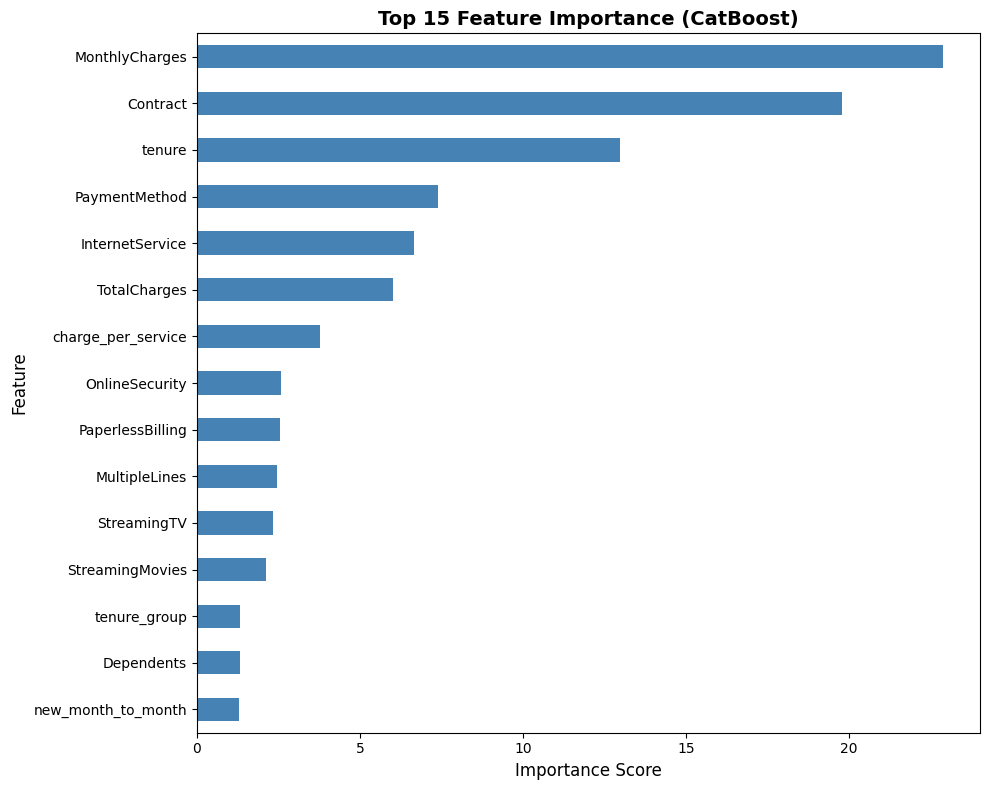

```
Top 10 Most Important Features:
  MonthlyCharges                  22.8685
  Contract                        19.7856
  tenure                          12.9656
  PaymentMethod                    7.3823
  InternetService                  6.6638
  TotalCharges                     6.0277
  charge_per_service               3.7821
  OnlineSecurity                   2.5709
  PaperlessBilling                 2.5588
  MultipleLines                    2.4684

Total features used: 26
Least important feature: has_internet
Most important feature: MonthlyCharges
```

```python
# Feature Importance Plot
feature_importance = best_model.get_feature_importance()
feature_names = X_encoded.columns

# Create dataframe and sort by importance
importance_df = pd.DataFrame({
    'feature': feature_names,
    'importance': feature_importance
}).sort_values('importance', ascending=True)

# Plot
fig, ax = plt.subplots(figsize=(10, 8))
importance_df.tail(15).plot(kind='barh', x='feature', y='importance', ax=ax, legend=False, color='steelblue')
ax.set_title('Top 15 Feature Importance (CatBoost)', fontsize=14, fontweight='bold')
ax.set_xlabel('Importance Score', fontsize=12)
ax.set_ylabel('Feature', fontsize=12)
plt.tight_layout()
plt.show()

# Display top 10 features
print("\nTop 10 Most Important Features:")
for idx, row in importance_df.tail(10).iloc[::-1].iterrows():
    print(f"  {row['feature']:<30} {row['importance']:>8.4f}")

print(f"\nTotal features used: {len(feature_names)}")
print(f"Least important feature: {importance_df.iloc[0]['feature']}")
print(f"Most important feature: {importance_df.iloc[-1]['feature']}")
```

```python
# Prepare data: Drop avg_monthly_charge and id columns
test_final= test_fe.copy()

# Convert tenure_group (categorical dtype) to string
test_final['tenure_group'] = test_final['tenure_group'].astype(str)

test_final = test_final.drop(['id', 'avg_monthly_charge'], axis=1)

# Identify categorical and numerical columns
categorical_cols = test_final.select_dtypes(include=['object']).columns.tolist()
numerical_cols = test_final.select_dtypes(include=['int64', 'float64']).columns.tolist()

print(f"Categorical features ({len(categorical_cols)}): {categorical_cols}")
print(f"Numerical features ({len(numerical_cols)}): {numerical_cols}")

# Encode categorical features for sklearn compatibility
label_encoders = {}
test_final_encoded = test_final.copy()

for col in categorical_cols:
    le = LabelEncoder()
    test_final_encoded[col] = le.fit_transform(test_final[col].astype(str))
    label_encoders[col] = le
```

```
Categorical features (16): ['gender', 'Partner', 'Dependents', 'PhoneService', 'MultipleLines', 'InternetService', 'OnlineSecurity', 'OnlineBackup', 'DeviceProtection', 'TechSupport', 'StreamingTV', 'StreamingMovies', 'Contract', 'PaperlessBilling', 'PaymentMethod', 'tenure_group']
Numerical features (6): ['SeniorCitizen', 'tenure', 'MonthlyCharges', 'TotalCharges', 'total_services', 'charge_per_service']
```

```python
test_final_encoded.head()
```

|  | gender | SeniorCitizen | Partner | Dependents | tenure | PhoneService | MultipleLines | InternetService | OnlineSecurity | OnlineBackup | ... | PaymentMethod | MonthlyCharges | TotalCharges | total_services | has_internet | tenure_group | charge_per_service | new_month_to_month | senior_with_dependents | has_family |
| --- | --- | --- | --- | --- | --- | --- | --- | --- | --- | --- | --- | --- | --- | --- | --- | --- | --- | --- | --- | --- | --- |
| 0 | 0 | 0 | 1 | 0 | 72 | 1 | 2 | 1 | 2 | 2 | ... | 2 | 115.55 | 8061.50 | 6 | 1 | 1 | 16.507143 | 0 | 0 | 1 |
| 1 | 0 | 0 | 1 | 0 | 71 | 1 | 0 | 2 | 1 | 1 | ... | 0 | 19.80 | 1336.50 | 0 | 0 | 1 | 19.800000 | 0 | 0 | 1 |
| 2 | 1 | 0 | 0 | 0 | 12 | 1 | 0 | 0 | 2 | 2 | ... | 0 | 55.55 | 633.55 | 2 | 1 | 2 | 18.516667 | 0 | 0 | 0 |
| 3 | 1 | 0 | 1 | 1 | 71 | 1 | 2 | 0 | 2 | 0 | ... | 1 | 84.10 | 6457.15 | 5 | 1 | 1 | 14.016667 | 0 | 0 | 1 |
| 4 | 0 | 0 | 0 | 0 | 15 | 1 | 0 | 1 | 2 | 0 | ... | 2 | 90.35 | 1233.65 | 3 | 1 | 0 | 22.587500 | 0 | 0 | 0 |

5 rows × 26 columns

```python
test_final_encoded['Churn']=best_model.predict(test_final_encoded)
```

```python
submission = test_final_encoded[['Churn']].copy()
submission['id'] = test['id']
```

```python
submission.to_csv(r'C:\Users\ivan5\Dropbox\Coursera\2. Kaggle\Customer Churn\submission.csv', index=False)
```

## Key Takeaways

Monthly Charges, Contract, Tenure, Payment Method and Internet service are the top 5 features with the most weight in the model.

Looking deeper in the EDA, the churning customers are mostly located in a high charge per service, low tenure, month to month contract and having Fiber Optic.

Suggested next steps:

1. Analyze the composition of the higher charges per service, which service(s) is(are) the one(s) that are more costly to the customer? This will tell us the main pain point.

   R-Churners in charges per service are mostly distributed in the higher end of charge per service. Looking at the plots we can tell that the company makes discounts based on the number of services they have acquired, however the trend is clear among all of them. I would suggest running an experiment where the cost is lowered just below the 1st quartile of the churners and see if it has any impact in the churn rate. Run a cost to benefit analysis, revenue per customer vs overall customer revenue and retention.
2. Analyze the low tenure class and see if there is any correlation with the service(s) found in the previous step.

   R- Low tenure and churning is mostly related to having Fiber Optic, I would suggest step 4 as a reference.

   Number customers who do not have internet service and churn: 2014

   Number customers who do not have internet service and do not churn: 138713

   Number customers who have internet service and churn: 131803

   Number customers who have internet service and do not churn: 321664
3. Analyze month to month contract similarly as the previous 2 steps.

R- High costs, low tenure and a month to month contract are the mix for churning.

4. Get data specifically to the service Fiber Optic related to: Complaints, Downtime, Competitors price, Time to install, Overall satisfaction. These will give us more insight and a clear path on where to invest money and improve the high-churn causes.
5. Further optmize model parameters and look into other model options: Logistic Regression, XGBoost, Decision Tree